# Day 3

## Tidyverse

## Tidyverse - 1

- the tidyverse is an opinionated collection of R packages designed for data science
- all packages share an underlying philosophy (‘tidy’) and common APIs

[figure not shown]

## Tidyverse - 2

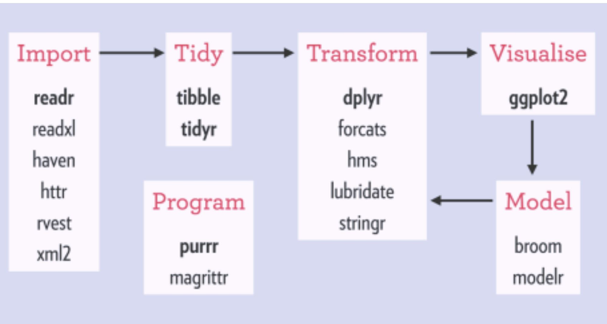

## Tidyverse - 3

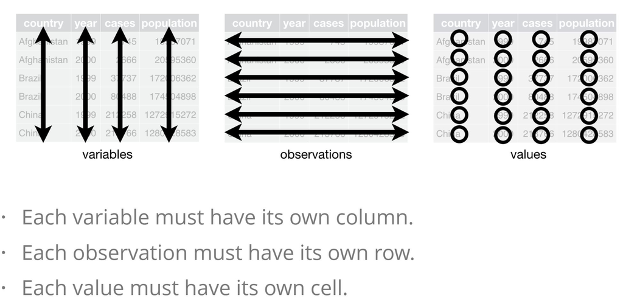

## Tidyverse - 4

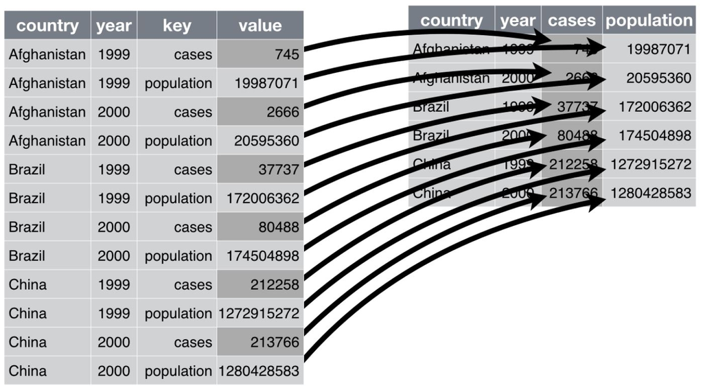

## Dplyr

- Hadley Wickham
- transforming data
- writing grammar with pipe operator (%>%)
- pipe operator in magrittr
- spread and gather in tidyr

## Grammar - 1

- select: return a subset of the columns of a data frame, using a flexible notation
- filter: extract a subset of rows from a data frame based on logical conditions
- arrange: reorder rows of a data frame
- rename: rename variables in a data frame

## Grammar - 2

- group_by() takes an existing tbl and converts it into a grouped tbl where operations are performed “by group”. ungroup() removes grouping
- mutate: add new variables/columns or transform existing variables
- summarise / summarize: generate summary statistics of different variables in the data frame, possibly within strata
- %>%: the “pipe” operator is used to connect multiple verb actions together into a pipeline

## Select - 1

- select(data.frame, columns)
- select(data.frame, column1:column3) – selects col1, col2, col3
- select(data.frame, -(col1:col3)) – selects all columns except col1 to col3
- starts_with() and ends_with()
- contains()

## Select - 2

- select_if: you specify the condition
- select_all(): you can manipulate

```r
df1<-iris%>%select_if(is.factor)
head(df1,2)
```

```
##   Species
## 1  setosa
## 2  setosa
```

```r
df2<-df1%>%select_all(toupper)
head(df2,2)
```

```
##   SPECIES
## 1  setosa
## 2  setosa
```

## %>%

- pipe operator
- stringing together multiple dplyr functions in a sequence of operations first(x) %>% second %>% third

## Arrange

- orders dataframe according to variables
- arrange(data.frame, col1)
- arrange(data.frame, desc(col1))

```r
iris%>%select(contains("Sepal"))%>%arrange(desc(Sepal.Width))%>%head(3)
```

```
##   Sepal.Length Sepal.Width
## 1          5.7         4.4
## 2          5.5         4.2
## 3          5.2         4.1
```

## Rename - 1

- renames columns
- rename(dataframe, newcol1=col1,newcol2=col2)
- new name is on the left side

```r
iris%>%select(contains("Sepal"))%>%arrange(desc(Sepal.Width))%>%
  rename(SepalW=Sepal.Width,
         SepalL=Sepal.Length)%>%head(3)
```

```
##   SepalL SepalW
## 1    5.7    4.4
## 2    5.5    4.2
## 3    5.2    4.1
```

## Rename - 2

- rename_with(.data, .fn, .cols = everything(), …)

```r
colName<-function(x) {
  tmp<-stringr::str_sub(x,1,7)
  return(gsub("\\.","",tmp))}
iris%>%rename_with(colName, contains("Sepal"))%>%head(3)
```

```
##   SepalL SepalW Petal.Length Petal.Width Species
## 1    5.1    3.5          1.4         0.2  setosa
## 2    4.9    3.0          1.4         0.2  setosa
## 3    4.7    3.2          1.3         0.2  setosa
```

## Summarise - 1

- create one or more scalar variables summarizing the variables of an existing tb
- powerfull with group_by clause

```r
iris%>%select(-Species)%>%
  summarise(numberOfRows=n())
```

```
##   numberOfRows
## 1          150
```

```r
iris%>%select(-Species)%>%
  summarise(median=median(Petal.Length),
            mean=mean(Petal.Length))
```

```
##   median  mean
## 1   4.35 3.758
```

## Summarise - 2

- summarise_at(): the input is character vector
- summarise_if(): using predicate function
- superseded with across function in dplyr v1.0.0

```r
columns<-c("Sepal.Length", "Sepal.Width", "Petal.Length", "Petal.Width")

iris%>%summarise_at(columns,.funs=list(mean, median))
```

```
##   Sepal.Length_fn1 Sepal.Width_fn1 Petal.Length_fn1 Petal.Width_fn1
## 1         5.843333        3.057333            3.758        1.199333
##   Sepal.Length_fn2 Sepal.Width_fn2 Petal.Length_fn2 Petal.Width_fn2
## 1              5.8               3             4.35             1.3
```

```r
iris%>%summarise_if(is.numeric,.funs=list(mean, median))
```

```
##   Sepal.Length_fn1 Sepal.Width_fn1 Petal.Length_fn1 Petal.Width_fn1
## 1         5.843333        3.057333            3.758        1.199333
##   Sepal.Length_fn2 Sepal.Width_fn2 Petal.Length_fn2 Petal.Width_fn2
## 1              5.8               3             4.35             1.3
```

## Summarise - 3

- across: applies funtion(s) to a set of colummns
- across(.cols = everything(), .fns = NULL, …, .names = NULL)

```r
columns<-c("Sepal.Length", "Sepal.Width", "Petal.Length", "Petal.Width")
iris%>%summarise(across(.cols=all_of(columns),.fns=list(mean, median)))
```

```
##   Sepal.Length_1 Sepal.Length_2 Sepal.Width_1 Sepal.Width_2 Petal.Length_1
## 1       5.843333            5.8      3.057333             3          3.758
##   Petal.Length_2 Petal.Width_1 Petal.Width_2
## 1           4.35      1.199333           1.3
```

```r
iris%>%summarise(across(.cols=is.numeric,.fns=list(mean, median)))
```

```
##   Sepal.Length_1 Sepal.Length_2 Sepal.Width_1 Sepal.Width_2 Petal.Length_1
## 1       5.843333            5.8      3.057333             3          3.758
##   Petal.Length_2 Petal.Width_1 Petal.Width_2
## 1           4.35      1.199333           1.3
```

## Mutate - 1

- computes new variables
- related verb transmute() which drops non transformed variables

```r
iris%>%mutate(AverageLength=(Sepal.Length+Petal.Length)/2,
              AverageWidth=(Sepal.Width+Petal.Width)/2)%>%
  head(3)
```

```
##   Sepal.Length Sepal.Width Petal.Length Petal.Width Species AverageLength
## 1          5.1         3.5          1.4         0.2  setosa          3.25
## 2          4.9         3.0          1.4         0.2  setosa          3.15
## 3          4.7         3.2          1.3         0.2  setosa          3.00
##   AverageWidth
## 1         1.85
## 2         1.60
## 3         1.70
```

## Mutate - 2

- mutate_at, mutate_if
- mutate+across

```r
iris%>%mutate_if(is.numeric, as.character)%>%head(.,3)
```

```
##   Sepal.Length Sepal.Width Petal.Length Petal.Width Species
## 1          5.1         3.5          1.4         0.2  setosa
## 2          4.9           3          1.4         0.2  setosa
## 3          4.7         3.2          1.3         0.2  setosa
```

```r
iris%>%mutate(across(.cols=is.numeric, .fns=as.character))%>%head(3)
```

```
##   Sepal.Length Sepal.Width Petal.Length Petal.Width Species
## 1          5.1         3.5          1.4         0.2  setosa
## 2          4.9           3          1.4         0.2  setosa
## 3          4.7         3.2          1.3         0.2  setosa
```

## Lab

- open dplyr.txt and complete the excercises

## Group_by

- used to generate summary statistics from the data frame within strata defined by a variable

```r
iris%>%group_by(Species)%>%summarise(across(.fns=list(mean, median)))
```

```
## # A tibble: 3 x 9
##   Species    Sepal.Length_1 Sepal.Length_2 Sepal.Width_1 Sepal.Width_2
##   <fct>               <dbl>          <dbl>         <dbl>         <dbl>
## 1 setosa               5.01            5            3.43           3.4
## 2 versicolor           5.94            5.9          2.77           2.8
## 3 virginica            6.59            6.5          2.97           3
## # ... with 4 more variables: Petal.Length_1 <dbl>, Petal.Length_2 <dbl>,
## #   Petal.Width_1 <dbl>, Petal.Width_2 <dbl>
```

## Slice helpers - 1

- top_n(), sample_n(), sample_frac()
- v1.0.0: slice_min(), slice_max(), slice_head(), slice_tail(), slice_sample()

```r
iris%>%top_n(2, wt=Petal.Width)
```

```
##   Sepal.Length Sepal.Width Petal.Length Petal.Width   Species
## 1          6.3         3.3          6.0         2.5 virginica
## 2          7.2         3.6          6.1         2.5 virginica
## 3          6.7         3.3          5.7         2.5 virginica
```

```r
iris%>%slice_max(order_by = Petal.Width, n=2)
```

```
##   Sepal.Length Sepal.Width Petal.Length Petal.Width   Species
## 1          6.3         3.3          6.0         2.5 virginica
## 2          7.2         3.6          6.1         2.5 virginica
## 3          6.7         3.3          5.7         2.5 virginica
```

## Slice helpers - 2

- without ties

```r
iris%>%slice_max(order_by = Petal.Width, n=2, with_ties=FALSE)
```

```
##   Sepal.Length Sepal.Width Petal.Length Petal.Width   Species
## 1          6.3         3.3          6.0         2.5 virginica
## 2          7.2         3.6          6.1         2.5 virginica
```

- random selection

```r
iris%>%sample_frac(size=0.03)
```

```
##   Sepal.Length Sepal.Width Petal.Length Petal.Width   Species
## 1          5.1         3.7          1.5         0.4    setosa
## 2          6.7         3.0          5.2         2.3 virginica
## 3          4.8         3.4          1.6         0.2    setosa
## 4          6.2         3.4          5.4         2.3 virginica
```

## Slice helpers - 3

- random selection with slice_sample()

```r
iris%>%slice_sample(prop=0.03)
```

```
##   Sepal.Length Sepal.Width Petal.Length Petal.Width    Species
## 1          6.6         3.0          4.4         1.4 versicolor
## 2          5.7         3.0          4.2         1.2 versicolor
## 3          7.7         3.8          6.7         2.2  virginica
## 4          6.7         3.1          4.7         1.5 versicolor
```

## Lab

- import Master.csv
- number of players by year of birth n()
- number of players per birthCountry (asc)
- average weight in kg per birthCountry (desc) where number of per birthcountry>5 help:
  - select birthyear
  - group by
  - summarise (use function n())
  - arrange

## Window rank functions - 1

- row_number
- ntile
- min_rank
- dense_rank

```r
df<-iris%>%slice_sample(n=10)
df%>%mutate(id=row_number(), groups=ntile(Species,5),
            minrank=min_rank(Species), denserank=dense_rank(Species))%>%
  select(-contains("Petal"),-contains("Sepal"),)
```

```
##       Species id groups minrank denserank
## 1   virginica  1      4       7         3
## 2  versicolor  2      2       4         2
## 3  versicolor  3      3       4         2
## 4   virginica  4      4       7         3
## 5   virginica  5      5       7         3
## 6   virginica  6      5       7         3
## 7      setosa  7      1       1         1
## 8      setosa  8      1       1         1
## 9  versicolor  9      3       4         2
## 10     setosa 10      2       1         1
```

## Window rank functions - 2

- how to add row_numbers in every group by decreasig size of Petal.Length
- how to get the second largest?

```r
df<-iris%>%slice_sample(n=10)
df%>%group_by(Species)%>%arrange(desc(Petal.Length))%>%
  mutate(id=row_number())%>%
  ungroup()%>%
  select(Petal.Length, Species, id)%>%arrange(Species)
```

```
## # A tibble: 10 x 3
##    Petal.Length Species       id
##           <dbl> <fct>      <int>
##  1          1.6 setosa         1
##  2          1.4 setosa         2
##  3          4   versicolor     1
##  4          3.8 versicolor     2
##  5          3.7 versicolor     3
##  6          3.6 versicolor     4
##  7          6.1 virginica      1
##  8          6   virginica      2
##  9          5.6 virginica      3
## 10          5.1 virginica      4
```

## Lab

- import Master.csv
- show the second heaviest man from the first 5 contries with the largest average weight in kg per birthCountry (desc) where number of per birthcountry>5

## Gather and spread (tidyr) - 1

- spread(key, value)
- gather(key, value)

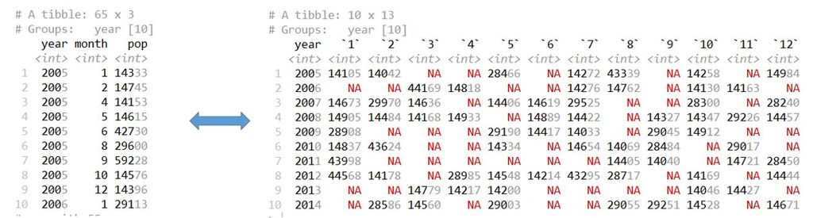

## Gather and spread (tidyr) - 2

- spread

```r
df<-airquality%>%select(Month, Day, Temp)%>%dplyr::filter(Month %in% c(5,6) & Day<4)%>%
  spread(key=Month, value=Temp)
df
```

```
##   Day  5  6
## 1   1 67 78
## 2   2 72 74
## 3   3 74 67
```

- gather

```r
df%>%gather(Month, Temp, - Day)
```

```
##   Day Month Temp
## 1   1     5   67
## 2   2     5   72
## 3   3     5   74
## 4   1     6   78
## 5   2     6   74
## 6   3     6   67
```

## Pivot_longer and pivot_wider (tidyr) - 1

- successors to spread and gather
- pivot_wider

```r
df<-airquality%>%select(Month, Day, Temp)%>%dplyr::filter(Month %in% c(5,6) & Day<4)%>%
  pivot_wider(names_prefix = "Month ", names_from=Month, values_from=Temp)
df
```

```
## # A tibble: 3 x 3
##     Day `Month 5` `Month 6`
##   <int>     <int>     <int>
## 1     1        67        78
## 2     2        72        74
## 3     3        74        67
```

## Pivot_longer and pivot_wider (tidyr) - 2

- pivot_longer

```r
df<-data.frame(day=c("Monday", "Tuesday","Wednesday"),month_aug=c(46,76,32),
               month_sep=c(62,67,23), month_oct=c(43,NA,31))
df
```

```
##         day month_aug month_sep month_oct
## 1    Monday        46        62        43
## 2   Tuesday        76        67        NA
## 3 Wednesday        32        23        31
```

```r
df%>%pivot_longer(cols=month_aug:month_oct, names_to = "Month",
                  values_to = "Temperature")%>%
  head(6)
```

```
## # A tibble: 6 x 3
##   day     Month     Temperature
##   <chr>   <chr>           <dbl>
## 1 Monday  month_aug          46
## 2 Monday  month_sep          62
## 3 Monday  month_oct          43
## 4 Tuesday month_aug          76
## 5 Tuesday month_sep          67
## 6 Tuesday month_oct          NA
```

## Pivot_longer and pivot_wider (tidyr) - 3

- using names_prefix and values_drop_na

```r
df%>%pivot_longer(cols=month_aug:month_oct,names_prefix="month_",
                  names_to = "Month", values_to = "Temperature", values_drop_na=TRUE) %>%
  head(6)
```

```
## # A tibble: 6 x 3
##   day       Month Temperature
##   <chr>     <chr>       <dbl>
## 1 Monday    aug            46
## 2 Monday    sep            62
## 3 Monday    oct            43
## 4 Tuesday   aug            76
## 5 Tuesday   sep            67
## 6 Wednesday aug            32
```

## Lab

- import norway_new_car_sales_by_model.xlsx
- show the number of sold cars by manufacturer (rows) and years(columns)
- use spread and pivot_wider

## User defined functions in dplyr - 1

- using in mutate
- function has to be vectorized; if not, use rowwise() to go row by row
- vectorized function

```r
fTOc<-function(x) {round((x-32)*5/9,0)}
input<-c(100, 102, 99)
fTOc(input)
```

```
## [1] 38 39 37
```

- nonvectorized function

```r
stupidFunction<-function(x,y){return(sum(x,y))}

airquality%>%mutate(something=stupidFunction(Month, Day))%>%head(3)
```

```
##   Ozone Solar.R Wind Temp Month Day something
## 1    41     190  7.4   67     5   1      3488
## 2    36     118  8.0   72     5   2      3488
## 3    12     149 12.6   74     5   3      3488
```

## User defined functions in dplyr - 2

- using rowwise() operation

```r
airquality%>%rowwise()%>%mutate(something=stupidFunction(Month, Day))%>%head(3)
```

```
## # A tibble: 3 x 7
## # Rowwise:
##   Ozone Solar.R  Wind  Temp Month   Day something
##   <int>   <int> <dbl> <int> <int> <int>     <int>
## 1    41     190   7.4    67     5     1         6
## 2    36     118   8      72     5     2         7
## 3    12     149  12.6    74     5     3         8
```

- or add id and use group_by(id)

```r
airquality%>%mutate(id=row_number())%>%group_by(id)%>%
  mutate(something=stupidFunction(Month, Day))%>%ungroup()%>%head(3)
```

```
## # A tibble: 3 x 8
##   Ozone Solar.R  Wind  Temp Month   Day    id something
##   <int>   <int> <dbl> <int> <int> <int> <int>     <int>
## 1    41     190   7.4    67     5     1     1         6
## 2    36     118   8      72     5     2     2         7
## 3    12     149  12.6    74     5     3     3         8
```

## User defined functions in dplyr - 3

- use Vectorize() function

```r
stupidFunction_v<-Vectorize(stupidFunction)
airquality%>%
  mutate(something=stupidFunction_v(Month, Day))%>%head(5)
```

```
##   Ozone Solar.R Wind Temp Month Day something
## 1    41     190  7.4   67     5   1         6
## 2    36     118  8.0   72     5   2         7
## 3    12     149 12.6   74     5   3         8
## 4    18     313 11.5   62     5   4         9
## 5    NA      NA 14.3   56     5   5        10
```

## Lab

- use Titanic dataset
- write a function, which will return the following:
  - if a person was a child and didn’t survive, the function should return “Poor child”
  - if a person was a woman and didn’t survive, the function should return “Oh no”
  - if a person was an adult man and did survive, the function should return “You shouldn’t save you if there were still women and children aboard”

## Lab

- take dataset mtcars
- write a function which will tranform mpg to l/100 kms and assign values to a new column consumption
- display mean and median for mpg, hp, consumption
- identify the worst and best economic car

## Join - 1

- inner_join
- left_join
- right_join
- full_join

## Join - 2

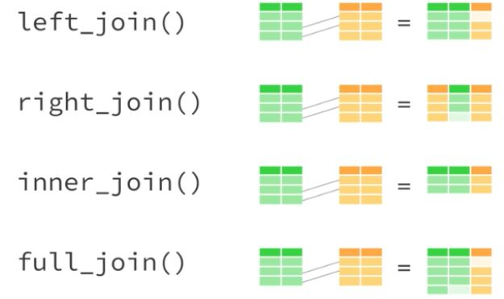

## Join - 3

- semi_join
- anti_join

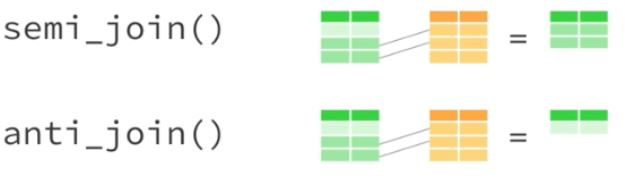

## Examples {.smaller}

```r
band_members%>%head()
```

```
## # A tibble: 3 x 2
##   name  band
##   <chr> <chr>
## 1 Mick  Stones
## 2 John  Beatles
## 3 Paul  Beatles
```

```r
band_instruments%>%head()
```

```
## # A tibble: 3 x 2
##   name  plays
##   <chr> <chr>
## 1 John  guitar
## 2 Paul  bass
## 3 Keith guitar
```

## Examples

```r
band_members %>% inner_join(band_instruments)
```

```
## # A tibble: 2 x 3
##   name  band    plays
##   <chr> <chr>   <chr>
## 1 John  Beatles guitar
## 2 Paul  Beatles bass
```

```r
band_members %>% left_join(band_instruments)
```

```
## # A tibble: 3 x 3
##   name  band    plays
##   <chr> <chr>   <chr>
## 1 Mick  Stones  <NA>
## 2 John  Beatles guitar
## 3 Paul  Beatles bass
```

## Examples

```r
band_members %>% right_join(band_instruments)
```

```
## # A tibble: 3 x 3
##   name  band    plays
##   <chr> <chr>   <chr>
## 1 John  Beatles guitar
## 2 Paul  Beatles bass
## 3 Keith <NA>    guitar
```

```r
band_members %>% full_join(band_instruments)
```

```
## # A tibble: 4 x 3
##   name  band    plays
##   <chr> <chr>   <chr>
## 1 Mick  Stones  <NA>
## 2 John  Beatles guitar
## 3 Paul  Beatles bass
## 4 Keith <NA>    guitar
```

## Examples

- A semi join differs from an inner join because an inner join will return one row of x for each matching row of y, where a semi join will never duplicate rows of x

```r
band_members %>% semi_join(band_instruments)
```

```
## # A tibble: 2 x 2
##   name  band
##   <chr> <chr>
## 1 John  Beatles
## 2 Paul  Beatles
```

```r
band_members %>% anti_join(band_instruments)
```

```
## # A tibble: 1 x 2
##   name  band
##   <chr> <chr>
## 1 Mick  Stones
```

## Joining by many columns, different names

- inner_join(df1, df2, by=c(“a1”=“b2”,“z3”=“u1”))

```r
d1 <- data_frame(
  x = letters[1:3],
  y = LETTERS[1:3],
  a = rnorm(3)
  )

d2 <- data_frame(
  x2 = letters[3:1],
  y2 = LETTERS[3:1],
  b = rnorm(3)
  )

left_join(d1, d2, by = c("x" = "x2", "y" = "y2"))
```

```
## # A tibble: 3 x 4
##   x     y           a      b
##   <chr> <chr>   <dbl>  <dbl>
## 1 a     A      0.601   0.600
## 2 b     B     -0.0297  0.560
## 3 c     C     -0.0783 -0.927
```

## Lab

- download csv 2019 version of data from http://www.seanlahman.com/baseball-archive/statistics/
- extract master.csv and FieldingOF.csv
- meta data are available at http://www.seanlahman.com/files/database/readme2019.txt
- Display the name (firstname+lastname) of the player who had the second highest number of games played in center field for each year from 1990 to 2000

## Lag and lead

- find the “previous” (lag()) or “next” (lead()) values in a vector

```r
r<-data.frame(year=2005:2014,population=sample(14000:15000, 10, replace=T))
r<-cbind(r,lag(r$population))
names(r)<-c("year","pop","pop1")
r%>%
  mutate(index=round(100*(1+(pop-pop1)/pop1),2))%>%
  select(year,pop,pop1,index)
```

```
##    year   pop  pop1 index
## 1  2005 14378 14378   100
## 2  2006 14480 14480   100
## 3  2007 14557 14557   100
## 4  2008 14953 14953   100
## 5  2009 14841 14841   100
## 6  2010 14016 14016   100
## 7  2011 14483 14483   100
## 8  2012 14029 14029   100
## 9  2013 14831 14831   100
## 10 2014 14360 14360   100
```

## Nested ifelse or case_when - 1

- nested ifelse

```r
df<-as.data.frame(Titanic)%>%select(Class, Sex, Age, Survived)%>%
  dplyr::filter(Class!="Crew")
dfIfElse<-df%>%
mutate(Comment=ifelse(Age=="Child" & Survived=="No","No Child should die!",
              ifelse(Age=="Adult" & Sex=="Male" & Survived=="Yes",
                    "He should help women and children!","No comment")))%>%
  slice_sample(n=10)
dfIfElse
```

```
##    Class    Sex   Age Survived                            Comment
## 1    2nd Female Adult       No                         No comment
## 2    3rd Female Adult       No                         No comment
## 3    1st   Male Child       No               No Child should die!
## 4    3rd   Male Adult       No                         No comment
## 5    1st Female Adult      Yes                         No comment
## 6    2nd   Male Child      Yes                         No comment
## 7    3rd   Male Adult      Yes He should help women and children!
## 8    1st Female Child       No               No Child should die!
## 9    1st Female Child      Yes                         No comment
## 10   3rd Female Child      Yes                         No comment
```

## Nested ifelse or case_when - 2

- case_when

```r
df%>%
  mutate(Comment=case_when(Age=="Child" & Survived=="No"~"No Child should die!",
  Age=="Adult" & Sex=="Male" & Survived=="Yes"~"He should help women and children!",
  TRUE~"No comment"))%>%
  slice_sample(n=10)
```

```
##    Class    Sex   Age Survived                            Comment
## 1    2nd Female Adult       No                         No comment
## 2    3rd   Male Adult      Yes He should help women and children!
## 3    2nd   Male Adult      Yes He should help women and children!
## 4    3rd Female Adult       No                         No comment
## 5    1st   Male Child       No               No Child should die!
## 6    3rd Female Child       No               No Child should die!
## 7    2nd Female Child       No               No Child should die!
## 8    1st   Male Adult       No                         No comment
## 9    2nd   Male Adult       No                         No comment
## 10   1st   Male Child      Yes                         No comment
```

## Unite and separate - 1

- unite combines multiple columns into a single column

```r
data<-as.data.frame(HairEyeColor)
head(data,4)
```

```
##    Hair   Eye  Sex Freq
## 1 Black Brown Male   32
## 2 Brown Brown Male   53
## 3   Red Brown Male   10
## 4 Blond Brown Male    3
```

- uniting Hair, Eye and Sex into Properties column

```r
data%>%unite("Properties",Hair:Sex, sep="/")%>%
  head(4)
```

```
##         Properties Freq
## 1 Black/Brown/Male   32
## 2 Brown/Brown/Male   53
## 3   Red/Brown/Male   10
## 4 Blond/Brown/Male    3
```

## Unite and separate - 2

- separate turns a single character column into multiple columns
- splitting the values of the column wherever a separator character appears

```r
df<-data%>%unite("Properties",Hair:Sex, sep="/")
df%>%separate(Properties, into=c("A","B","C"),sep="/")%>%
  head(3)
```

```
##       A     B    C Freq
## 1 Black Brown Male   32
## 2 Brown Brown Male   53
## 3   Red Brown Male   10
```

- what about in this case?

```r
df<-data.frame(name=c("Sam Jones Sr. Mr.",
                      "Lady Gaga Singer",
                      "Valentino Rossi Mr. (Junior) son")); df
```

```
##                               name
## 1                Sam Jones Sr. Mr.
## 2                 Lady Gaga Singer
## 3 Valentino Rossi Mr. (Junior) son
```

## Unite and separate - 3

- separate has extra atribute, which decides, what to with “extra data”

```r
df%>%separate(name, into=c("First_name","Last_Name"), extra="drop")
```

```
##   First_name Last_Name
## 1        Sam     Jones
## 2       Lady      Gaga
## 3  Valentino     Rossi
```

- fill: what happens when there are not enough pieces

```r
df%>%separate(name,
into=c("First_name","Last_Name","Something","Title"), extra="drop", fill="left")
```

```
##   First_name Last_Name Something  Title
## 1        Sam     Jones        Sr     Mr
## 2       <NA>      Lady      Gaga Singer
## 3  Valentino     Rossi        Mr Junior
```

## Nest and unnest

- nesting creates a list-column of data frames
- nesting is implicitly a summarising operation
- convenient for bulding the models

```r
df<-iris%>%nest(-Species)
df
```

```
## # A tibble: 3 x 2
##   Species    data
##   <fct>      <list>
## 1 setosa     <tibble [50 x 4]>
## 2 versicolor <tibble [50 x 4]>
## 3 virginica  <tibble [50 x 4]>
```

```r
df%>%unnest()%>%head(2)
```

```
## # A tibble: 2 x 5
##   Species Sepal.Length Sepal.Width Petal.Length Petal.Width
##   <fct>          <dbl>       <dbl>        <dbl>       <dbl>
## 1 setosa           5.1         3.5          1.4         0.2
## 2 setosa           4.9         3            1.4         0.2
```

## Lab

```
1. Take airmiles dataset and transform dataframe to a column with name Airmiles.
Add a new column called Year from 1937 to 1960.
Calculate index for Airmiles. Which year has the highest index.
2. Take dates_df dataframe and split date column into columns month, day and year!
dates_df <- data.frame(date = c("5/24/1930",
                                "5/25/1930",
                                "5/26/1930",
                                "5/27/1930",
                                "5/28/1930"),
                       stringsAsFactors = FALSE)
3. Create 100 random numbers between 1 and 95 and transform it to a column Age in a dataframe
People.
Discretize Age into the following age groups:
- 1:20
- 21:45
- 46:55
- 56:70
- 71:
Calculate summary statistics.
```

## map family functions - 1

- purrr package
- map familiy functions transform their input by applying a function to each element of a list or atomic vector and returning an object of the same length as the input
- map(): returns a list
- map_lgl(), map_int(), map_dbl() and map_chr() return an atomic vector of the indicated type
- map_df(), map_dfr() and map_dfc() return a data frame created by row-binding and column-binding
- there are also map_if and map_at functions, where logic is the same as with _if and _at functions till now.

```r
airquality%>%select(Ozone)%>%
  map(mean)
```

```
## $Ozone
## [1] NA
```

## map family functions - 2

- one function, no arguments: map
- one function with 2 arguments: map2
- one function with many arguments: pmap

## map family functions - 3

```r
airquality%>%select(Temp)%>%
  map(mean)
```

```
## $Temp
## [1] 77.88235
```

## map family functions - 4

- reading files with the same structure, map_df

```r
files<-list.files(pattern = "*.csv", path = "./Mtcars/",  full.names = TRUE)

allDF<-map_df(files, read.csv2)
```

- calling more than 1 function in map
- invoke, invoke_map: retired

```r
airquality%>%select(Ozone)%>%invoke_map(.f=c("mean", "max"),na.rm=TRUE)
```

[output not shown]

## map family functions - 5

```r
airquality%>%select(Month, Day)%>%mutate(Something=map2_int(Month,Day,sum))%>%
  head(3)%>%as_tibble()
```

```
## # A tibble: 3 x 3
##   Month   Day Something
##   <int> <int>     <int>
## 1     5     1         6
## 2     5     2         7
## 3     5     3         8
```

```r
airquality%>%select(Month, Day)%>%mutate(Something=map2_chr(Month,Day,sum))%>%
  head(3)%>%as_tibble()
```

```
## # A tibble: 3 x 3
##   Month   Day Something
##   <int> <int> <chr>
## 1     5     1 6
## 2     5     2 7
## 3     5     3 8
```

## map family functions - 6

- map handles vectorization

```r
stupidFunction<-function(x,y){return(sum(x,y))}

airquality%>%select(Month, Day)%>%
  mutate(Something=map2_chr(Month,Day,stupidFunction))%>%
  head(3)%>%as_tibble()
```

```
## # A tibble: 3 x 3
##   Month   Day Something
##   <int> <int> <chr>
## 1     5     1 6
## 2     5     2 7
## 3     5     3 8
```

## map family functions - 7

- pmap: arbitrary number of arguments

```r
airquality%>%select(Wind,Temp, Month, Day)%>%
  mutate(Something=pmap_dbl(list(Wind,Temp,Month,Day),sum))%>%
  head(3)%>%as_tibble()
```

```
## # A tibble: 3 x 5
##    Wind  Temp Month   Day Something
##   <dbl> <int> <int> <int>     <dbl>
## 1   7.4    67     5     1      80.4
## 2   8      72     5     2      87
## 3  12.6    74     5     3      94.6
```

```r
airquality%>%select(Wind,Temp, Month, Day)%>%
  mutate(Something=pmap_chr(list(Wind,Temp,Month,Day),sum))%>%
  head(3)%>%as_tibble()
```

```
## # A tibble: 3 x 5
##    Wind  Temp Month   Day Something
##   <dbl> <int> <int> <int> <chr>
## 1   7.4    67     5     1 80.400000
## 2   8      72     5     2 87.000000
## 3  12.6    74     5     3 94.600000
```

## map family functions - 8

- passing additional arguments to function

```r
airquality%>%select(Ozone,Day)%>%dplyr::filter(is.na(Ozone))%>%
  mutate(Something=map2_int(Ozone,Day,max))%>%
  head(3)%>%as_tibble()
```

```
## # A tibble: 3 x 3
##   Ozone   Day Something
##   <int> <int>     <int>
## 1    NA     5        NA
## 2    NA    10        NA
## 3    NA    25        NA
```

```r
airquality%>%select(Ozone,Day)%>%dplyr::filter(is.na(Ozone))%>%
  mutate(Something=map2_int(Ozone,Day,max, na.rm=TRUE))%>%
  head(3)%>%as_tibble()
```

```
## # A tibble: 3 x 3
##   Ozone   Day Something
##   <int> <int>     <int>
## 1    NA     5         5
## 2    NA    10        10
## 3    NA    25        25
```

## map family functions - 9

- passing more than one argument to called function

```r
files<-list.files(pattern = "*.csv", path = "./Mtcars/",  full.names = TRUE)

allDF<-map_df(files, read.csv2, skip=1,header=FALSE)
```

## Example of more complex use - 1

- creating a linear model for every number of cyl
- when functions get more complex there are basically two ways to call them either with the tilde notation or with a normal anonymous function

```r
call1<-mtcars%>%select(cyl,mpg,wt)%>%
  nest(-cyl)%>%mutate(model=map(data,function(x) lm(formula=mpg~wt,data=x)))

call2<-mtcars%>%select(cyl,mpg,wt)%>%
  nest(-cyl)%>%mutate(model=map(data,~lm(formula=mpg~wt,data=.x)))
call1
```

```
## # A tibble: 3 x 3
##     cyl data              model
##   <dbl> <list>            <list>
## 1     6 <tibble [7 x 2]>  <lm>
## 2     4 <tibble [11 x 2]> <lm>
## 3     8 <tibble [14 x 2]> <lm>
```

## Example of more complex use - 2

- pluck

```r
call1%>%pluck("data",1)
```

```
## # A tibble: 7 x 2
##     mpg    wt
##   <dbl> <dbl>
## 1  21    2.62
## 2  21    2.88
## 3  21.4  3.22
## 4  18.1  3.46
## 5  19.2  3.44
## 6  17.8  3.44
## 7  19.7  2.77
```

## Example of more complex use - 3

- making tidy models

```r
call1%>%mutate(tidyModel=map(model, tidy))%>%
  unnest(tidyModel)
```

```
## # A tibble: 6 x 8
##     cyl data              model  term        estimate std.error statistic p.value
##   <dbl> <list>            <list> <chr>          <dbl>     <dbl>     <dbl>   <dbl>
## 1     6 <tibble [7 x 2]>  <lm>   (Intercept)    28.4      4.18       6.79 1.05e-3
## 2     6 <tibble [7 x 2]>  <lm>   wt             -2.78     1.33      -2.08 9.18e-2
## 3     4 <tibble [11 x 2]> <lm>   (Intercept)    39.6      4.35       9.10 7.77e-6
## 4     4 <tibble [11 x 2]> <lm>   wt             -5.65     1.85      -3.05 1.37e-2
## 5     8 <tibble [14 x 2]> <lm>   (Intercept)    23.9      3.01       7.94 4.05e-6
## 6     8 <tibble [14 x 2]> <lm>   wt             -2.19     0.739     -2.97 1.18e-2
```

## Lab

- Write a function called n_unique, which will return the number of distinct values. Apply this function to a dataframe mtcars. Which column has a highest variability (most different distinct values)?
- Use the appropriate map() function to:
  - Compute the standard deviation of every column in a numeric data frame (mtcars)
  - Compute the standard deviation of every numeric column in a mixed data frame(iris)
  - Compute the number of levels for every factor in a data frame (iris)

## Tabular representation with gt()

- gt package

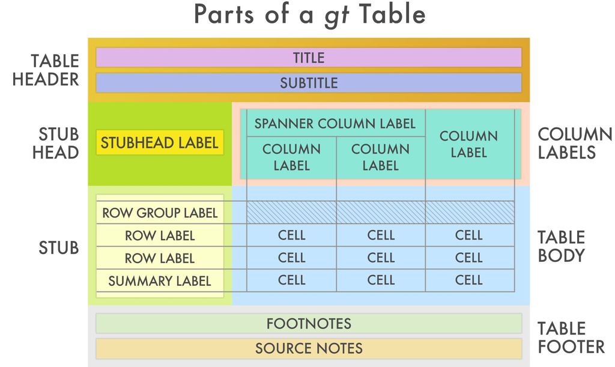

## Simple gt object

```r
df<-sp500 %>%
  dplyr::filter(between(date,ymd("2015-12-24"),ymd("2015-12-31"))) %>%
  select(-adj_close) %>% arrange(date)
  df %>% gt()
```

| date | open | high | low | close | volume |
| --- | --- | --- | --- | --- | --- |
| 2015-12-24 | 2063.52 | 2067.36 | 2058.73 | 2060.99 | 1411860000 |
| 2015-12-28 | 2057.77 | 2057.77 | 2044.20 | 2056.50 | 2492510000 |
| 2015-12-29 | 2060.54 | 2081.56 | 2060.54 | 2078.36 | 2542000000 |
| 2015-12-30 | 2077.34 | 2077.34 | 2061.97 | 2063.36 | 2367430000 |
| 2015-12-31 | 2060.59 | 2062.54 | 2043.62 | 2043.94 | 2655330000 |

## Adding title and formating columns

- fmt_*

```r
dfGT<-df %>% gt() %>%
  tab_header(title="SP500",
             subtitle="Last week of 2015") %>%
   fmt_date(columns = vars(date),date_style = 7) %>%
   fmt_currency(columns = vars(open, high, low, close),
    currency = "EUR")

dfGT
```

SP500

Last week of 2015

| date | open | high | low | close | volume |
| --- | --- | --- | --- | --- | --- |
| 24 dec. 2015 | €2,063.52 | €2,067.36 | €2,058.73 | €2,060.99 | 1411860000 |
| 28 dec. 2015 | €2,057.77 | €2,057.77 | €2,044.20 | €2,056.50 | 2492510000 |
| 29 dec. 2015 | €2,060.54 | €2,081.56 | €2,060.54 | €2,078.36 | 2542000000 |
| 30 dec. 2015 | €2,077.34 | €2,077.34 | €2,061.97 | €2,063.36 | 2367430000 |
| 31 dec. 2015 | €2,060.59 | €2,062.54 | €2,043.62 | €2,043.94 | 2655330000 |

## Adding groups - 1

```r
dfgt <- sp500 %>%
  mutate(year=year(date),wday=wday(date, label=TRUE, abbr=FALSE, locale = "english"))%>%
  select(year, wday, high, low) %>%
  group_by(year, wday) %>%
  summarise(high=mean(high), low=mean(low)) %>%
  dplyr::filter(year %in% c(2014,2015)) %>%
  ungroup()

dfgt
```

```
## # A tibble: 10 x 4
##     year wday       high   low
##    <dbl> <ord>     <dbl> <dbl>
##  1  2014 Monday    1941. 1925.
##  2  2014 Tuesday   1940. 1924.
##  3  2014 Wednesday 1941. 1925.
##  4  2014 Thursday  1933. 1914.
##  5  2014 Friday    1939. 1923.
##  6  2015 Monday    2072. 2050.
##  7  2015 Tuesday   2070. 2047.
##  8  2015 Wednesday 2072. 2049.
##  9  2015 Thursday  2073. 2051.
## 10  2015 Friday    2072. 2050.
```

## Adding groups - 2

- rowname_col

```r
dfgt %>% gt(rowname_col = "year") %>%
  fmt_currency(columns=vars(high,low), currency = "EUR")
```

|  | wday | high | low |
| --- | --- | --- | --- |
| 2014 | Monday | €1,941.05 | €1,924.95 |
| 2014 | Tuesday | €1,940.11 | €1,924.20 |
| 2014 | Wednesday | €1,940.99 | €1,925.14 |
| 2014 | Thursday | €1,932.90 | €1,913.93 |
| 2014 | Friday | €1,939.08 | €1,923.17 |
| 2015 | Monday | €2,071.82 | €2,049.77 |
| 2015 | Tuesday | €2,070.48 | €2,047.26 |
| 2015 | Wednesday | €2,071.74 | €2,048.60 |
| 2015 | Thursday | €2,073.29 | €2,051.18 |
| 2015 | Friday | €2,072.02 | €2,049.98 |

## Adding groups - 3

- groupname_col

```r
dfgtL<-dfgt %>% gt(groupname_col = "year") %>% fmt_currency(columns=vars(high,low),                           currency = "EUR")
dfgtL
```

| wday | high | low |
| --- | --- | --- |
| 2014 |  |  |
| Monday | €1,941.05 | €1,924.95 |
| Tuesday | €1,940.11 | €1,924.20 |
| Wednesday | €1,940.99 | €1,925.14 |
| Thursday | €1,932.90 | €1,913.93 |
| Friday | €1,939.08 | €1,923.17 |
| 2015 |  |  |
| Monday | €2,071.82 | €2,049.77 |
| Tuesday | €2,070.48 | €2,047.26 |
| Wednesday | €2,071.74 | €2,048.60 |
| Thursday | €2,073.29 | €2,051.18 |
| Friday | €2,072.02 | €2,049.98 |

## Adding summary labels - 1

- summary_rows

```r
dfgt %>% dplyr::filter(wday %in% c("Monday","Tuesday")) %>%
  gt(groupname_col = "year") %>% fmt_currency(columns=vars(high,low),
    currency = "EUR") %>%
    summary_rows(
    columns = vars(high, low),
    fns = list(average = "mean"))
```

|  | wday | high | low |
| --- | --- | --- | --- |
| 2014 |  |  |  |
|  | Monday | €1,941.05 | €1,924.95 |
|  | Tuesday | €1,940.11 | €1,924.20 |
| 2015 |  |  |  |
|  | Monday | €2,071.82 | €2,049.77 |
|  | Tuesday | €2,070.48 | €2,047.26 |
| average | — | 2,005.86 | 1,986.54 |

## Adding summary labels - 2

- summary_rows by groups

```r
dfgt %>% dplyr::filter(wday %in% c("Monday","Tuesday")) %>%
  gt(groupname_col = "year", rowname_col ="wday") %>%
  fmt_currency(columns=vars(high,low),currency = "EUR") %>%
    summary_rows(
    groups = TRUE,
    columns = vars(high, low),
    fns = list(
      avg = ~mean(., na.rm = TRUE),
      total = ~sum(., na.rm = TRUE),
      s.d. = ~sd(., na.rm = TRUE)
    )
  )
```

## Adding summary labels - 4

|  | high | low |
| --- | --- | --- |
| 2014 |  |  |
| Monday | €1,941.05 | €1,924.95 |
| Tuesday | €1,940.11 | €1,924.20 |
| avg | 1,940.58 | 1,924.57 |
| total | 3,881.16 | 3,849.15 |
| s.d. | 0.66 | 0.53 |
| 2015 |  |  |
| Monday | €2,071.82 | €2,049.77 |
| Tuesday | €2,070.48 | €2,047.26 |
| avg | 2,071.15 | 2,048.51 |
| total | 4,142.30 | 4,097.03 |
| s.d. | 0.94 | 1.77 |